# Python for Climate and Water Professionals

Introduction

Addisu G. Semie.

2023-03-06

# Python Programming Language

**Python** is a **high-level**, **interpreted**, **object oriented**, and **general purpose** programming language.

**Basic Concepts**

- **High-Level Language:** programmer-friendly languages that are easy to understand, debug, and widely used in today’s times (E.g. Python, Java, C, FORTRAN).
- **Low-Level Language:** machine-friendly languages that are very difficult to understand by human beings but easy to interpret by machines (E.g., machine language & Assembly language).

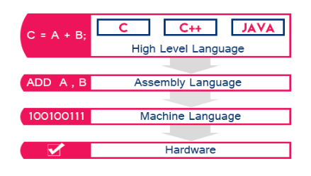

**Hello world in Assembly Language**

```
global _start

section .text

_start:
  mov rax, 1        ; write(
  mov rdi, 1        ;   STDOUT_FILENO,
  mov rsi, msg      ;   "Hello, world!\n",
  mov rdx, msglen   ;   sizeof("Hello, world!\n")
  syscall           ; );

  mov rax, 60       ; exit(
  mov rdi, 0        ;   EXIT_SUCCESS
  syscall           ; );

section .rodata
  msg: db "Hello, world!", 10
  msglen: equ $ - msg
```

**To run it**:

```
sudo apt install nasm
nasm -f elf64 -o hello.o hello.asm
ld -o hello hello.o
./hello
```

- **Compiler and Interpreter**: translates *source code* written in a high-level language (e.g., C, C++, Fortran) into a set of *machine-language* that can be understood by the computer’s CPU.

| Languages | Compiler | Compiler Name |
| --- | --- | --- |
| C | GNU | gcc |
|  | Intel | icc |
| C++ | GNU | g++ |
|  | Intel | icpc |
| Fortran | gfortran | gfortran |
|  | Intel | ifort |

- **Compiled Language:**
  - are converted directly into machine code that the processor can execute (E.g., C, C++, FORTRAN).
  - They tend to be faster and more efficient to execute than interpreted languages.
  - The disadvantages include no interaction during development, mandatory compilation steps, and manual memory management.
  - These are difficult languages for non programmers.

**Hello world in C Language**

```
#include <stdio.h>
int main() {
   printf("Hello, World!");
   return 0;
}
```

**To execute C program**:

```
gcc -o hello hello.c
./hello
```

**Hello world in Fortran Language**

```
program hello
  print *, 'Hello, World!'
end program hello
```

**To execute the Fortran Program**:

```
gfortran -o hello hello.f90
./hello
```

- **Interpreted Language:** run program line by line and execute each command (small chunks of code). They tend to be slower than compiled languages (e.g., PHP, Ruby, JavaScript, Python and R).

**Hello world in Python Language**

```
print('Hello, world!')
```

**To execute the Python Program as a Script**:

```
#!/usr/bin/env python3
print('Hello, world!')

chmod +x hello.py
./hello.py
```

# Why is Python so popular?

- Available on all major platforms (Windows, macOS, Linux)
- Automatic memory management: No need to explicitly allocate and deallocate memory for variables and data arrays.
- It is easy to learn, simple syntax, beginner friendly, easier to read and understand (*You are scientist not programmers*).
- Suitable for rapid development, prototyping, and good for experimenting.
- It’s versatile: Python can be used from web development to machine learning.
- It’s open source, which means it;s free to use and distribute, even for commercial purposes.
- Python has a very rich collection of libraries and packages.

# Downsides of Python?

- It’s slow.
- There is a smaller legacy code base: there are still many specific areas where no python solution is available: https://partee.io/2021/02/21/climate-model-response/

# Application of Python for meteorologists

- **Rich libraries and frameworks:** Python has a vast collection of libraries and frameworks that can be used for meteorological data analysis, visualization, and modeling. Popular libraries include NumPy, Pandas, Matplotlib, Cartopy, and MetPy
- **Easy to learn and use:** Python is an easy-to-learn and easy-to-use language, making it a great choice for meteorologists who may not have a strong background in computer science.
- **Interoperability:** Python can easily integrate with other programming languages such as Fortran and C, which are commonly used in meteorological modeling.
- **Open source:** Python is an open-source language, meaning it’s freely available for use and modification. This makes it easy for meteorologists to share and collaborate on code and models.
- **Large community support:** Python has a large and active community of users, including many meteorologists, who contribute to the development of libraries and frameworks, provide support and guidance, and share knowledge and best practices.
- **Platform-independent:** Python code can run on multiple operating systems, including Windows, Linux, and Mac OS, which makes it easy to use in various meteorological research environments.

# Introducing Jupyter notebooks

- **Jupyter notebooks** allows us to easily take notes about our analysis and view plots within the same document where we code.
- This facilitates sharing and reproducibility of analyses, and the notebook interface is easily accessible through any web browser.

# Starting Jupyter notebooks from terminal

**Jupyter notebooks are started from the terminal using**

Bash

$ jupyter-notebook

Your browser should start automatically and look something like this:

[figure not shown]

# Create a notebook

**When you create a notebook from the New option, the new notebook will be displayed in a new browser tab and look like this.**

[figure not shown]

- The notebook has no name other than ‘Untitled’. If you click on ‘Untitled’ you will be given the option of changing the name to whatever you want.
- The notebook is divided into **cells**

# Python code into the cell

- To interpret the code in a cell, you can click the Run button in the toolbar or from the Cell menu option, or use keyboard shortcuts (e.g., Shift+Return).
- All of the code in that cell will then be executed.

[figure not shown]

# Markdown

- Markdown is a simple formatting system which allows you to create documentation for your code, again all within the same notebook structure.
- You can change the cell type from Python code to Markdown using the Cell > Cell Type option.

.